# Visualisation Using Python: matplotlib

# Contents:

1. **matplotlib** Package
2. Figures vs Axes
3. Two API modes
4. **Object-Oriented API** $\leftarrow$

```python
import pandas as pd
import numpy as np
```

# 01. matplotlib Package

- comprehensive library for creating static, animated, and interactive visualizations in Python
- multi-platform data visualisation library **built on NumPy arrays**
- forms basis of many other popular Python plotting packages

Further Reading:

- https://matplotlib.org/index.html

### how to import? alias?

```python
import matplotlib.pyplot as plt
```

Further Reading:

- https://matplotlib.org/stable/api/_as_gen/matplotlib.pyplot.html?highlight=pyplot#module-matplotlib.pyplot

# 02. Anatomy of a Figure: Figures vs Axes

Figure = the whole figure

- axes
  - 2D vs 3D
- canvas
  - where everything is drawn
- artists
  - anything drawn on the canvas
- axes
  - 2D vs 3D
    - data is plotted within Axes
  - labels of the x and y axes
  - tick spacing
  - legends
  - etc
- canvas
  - where everything is drawn
  - i.e. upon which plots shown, one or more plots
    - may contain several axes
  - effectively invisible by user
- artists
  - anything drawn on the canvas
    - titles,
    - figure legends,
    - colour of the background,
    - etc
    - even the Figure, Axes, and Axis objects

Further Reading:

- https://matplotlib.org/faq/usage_faq.html#usage
- artists
  - https://matplotlib.org/api/artist_api.html
  - https://matplotlib.org/tutorials/intermediate/artists.html

# 03. API modes

- two approaches to plotting with Matplotlib
  - Object Oriented API (follows the Python object model)
  - MATLAB-like API (aka pyplot API)

Further Reading:

- https://matplotlib.org/api/index.html
- https://matplotlib.org/tutorials/introductory/lifecycle.html

# 04. Object Oriented API

1. Create a Figure object
- Using a figure method to create one or more Axes (within the Figure object)
- Using the axes object method create one or more plots within (for each axes)

### Demonstration: trigonometric functions

$\sin(x)$

```python
X = np.arange(0, 2*np.pi, 0.01); X[0:10]
```

```
array([0.  , 0.01, 0.02, 0.03, 0.04, 0.05, 0.06, 0.07, 0.08, 0.09])
```

```python
print(f'The value of pi in numpy is approx {np.pi:.5f}') # using formatted string literals
print(f"there are {len(X)} data points")
```

```
The value of pi in numpy is approx 3.14159
there are 629 data points
```

```python
Y = np.sin(X)
Y[0:10]
```

```
array([0.        , 0.00999983, 0.01999867, 0.0299955 , 0.03998933,
       0.04997917, 0.05996401, 0.06994285, 0.07991469, 0.08987855])
```

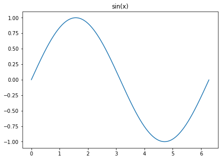

```python
fig = plt.figure() # figsize defaults = [6.4, 4.8] = inches

fig = plt.figure(figsize=(7,5))

ax = fig.add_subplot(1, 1, 1, title='sin(x)')
#                    n axes in row
#                       n axes in col
#                          index of this axis

ax.plot(X,Y)
```

how does the figure object work?

- to understand, let's plot a graph of $\cos(x)$ below the graph of $\sin(x)$

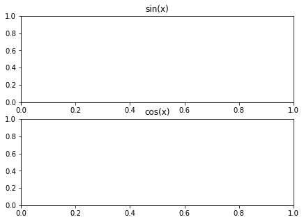

```python
fig = plt.figure(figsize=(7,5))

ax1 = fig.add_subplot(2, 1, 1, title='sin(x)')
ax2 = fig.add_subplot(2, 1, 2, title='cos(x)') # add the subplot
```

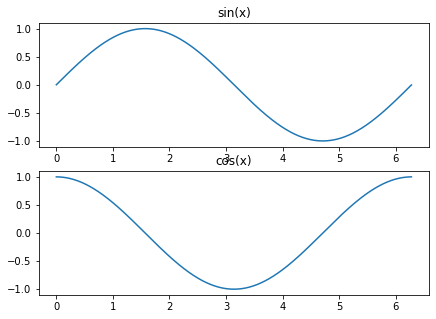

```python
fig = plt.figure(figsize=(7,5))

ax1 = fig.add_subplot(2, 1, 1, title='sin(x)')
ax1.plot(X,Y)

ax2 = fig.add_subplot(2, 1, 2, title='cos(x)')
Y2 = np.cos(X) # can define data within the usage of matplotlib
ax2.plot(X,Y2) # overlaps between axes objects --> fix on next slide
```

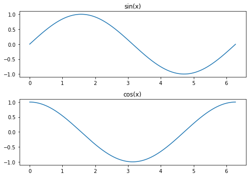

```python
fig = plt.figure(figsize=(7,5))

ax1 = fig.add_subplot(2, 1, 1, title='sin(x)')
ax1.plot(X,Y)
ax2 = fig.add_subplot(2, 1, 2, title='cos(x)')
ax2.plot(X,Y2)

plt.tight_layout() # resize subplots in a figure
                   # so that there are no overlaps
                   # between axes objects and labels on the axes
```

#### (sometimes/*usually*) better to have data prior to the usage of matplotlib

```python
Y1 = np.sin(X)      # trigonometric sine
Y2 = np.cos(X)      # cosine
Y3 = np.arcsinh(X)  # inverse hyperbolic sine
Y4 = np.cosh(X)     # hyperbolic cosine
```

Further Reading:

- https://numpy.org/doc/stable/reference/routines.math.html

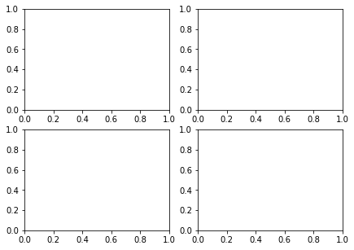

```python
fig = plt.figure(figsize=(7,5))

#                     2 axes in row
#                        2 axes in col
#                           index of this axis
ax1 = fig.add_subplot(2, 2, 1)
ax2 = fig.add_subplot(2, 2, 2)
ax3 = fig.add_subplot(2, 2, 3)
ax4 = fig.add_subplot(2, 2, 4)
```

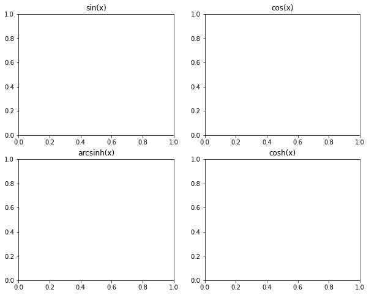

```python
fig = plt.figure(figsize=(10,8))

ax1 = fig.add_subplot(2, 2, 1, title='sin(x)')
ax2 = fig.add_subplot(2, 2, 2, title='cos(x)')
ax3 = fig.add_subplot(2, 2, 3, title='arcsinh(x)')
ax4 = fig.add_subplot(2, 2, 4, title='cosh(x)')
```

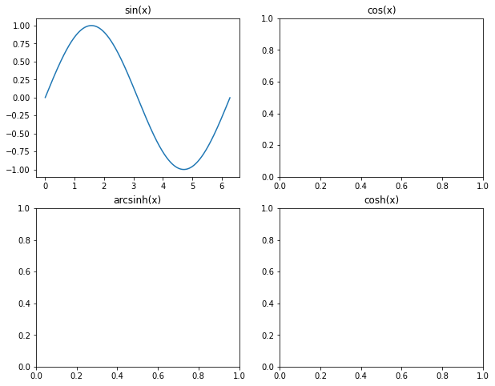

```python
fig = plt.figure(figsize=(10,8))

ax1 = fig.add_subplot(2, 2, 1, title='sin(x)');     ax1.plot(X,Y1)
ax2 = fig.add_subplot(2, 2, 2, title='cos(x)');
ax3 = fig.add_subplot(2, 2, 3, title='arcsinh(x)');
ax4 = fig.add_subplot(2, 2, 4, title='cosh(x)');
```

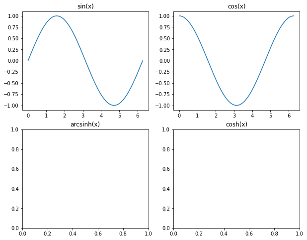

```python
fig = plt.figure(figsize=(10,8))

ax1 = fig.add_subplot(2, 2, 1, title='sin(x)');     ax1.plot(X,Y1)
ax2 = fig.add_subplot(2, 2, 2, title='cos(x)');     ax2.plot(X,Y2)
ax3 = fig.add_subplot(2, 2, 3, title='arcsinh(x)');
ax4 = fig.add_subplot(2, 2, 4, title='cosh(x)');
```

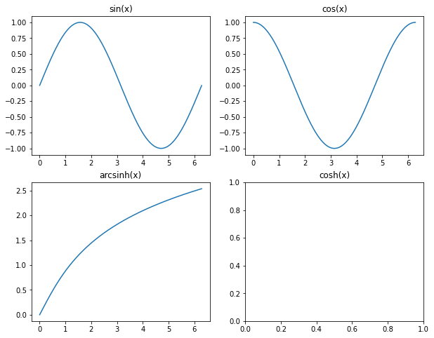

```python
fig = plt.figure(figsize=(10,8))

ax1 = fig.add_subplot(2, 2, 1, title='sin(x)');     ax1.plot(X,Y1)
ax2 = fig.add_subplot(2, 2, 2, title='cos(x)');     ax2.plot(X,Y2)
ax3 = fig.add_subplot(2, 2, 3, title='arcsinh(x)'); ax3.plot(X,Y3)
ax4 = fig.add_subplot(2, 2, 4, title='cosh(x)');
```

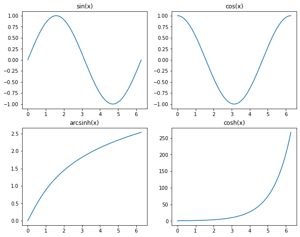

```python
fig = plt.figure(figsize=(10,8))

ax1 = fig.add_subplot(2, 2, 1, title='sin(x)');     ax1.plot(X,Y1)
ax2 = fig.add_subplot(2, 2, 2, title='cos(x)');     ax2.plot(X,Y2)
ax3 = fig.add_subplot(2, 2, 3, title='arcsinh(x)'); ax3.plot(X,Y3)
ax4 = fig.add_subplot(2, 2, 4, title='cosh(x)');    ax4.plot(X,Y4)
```

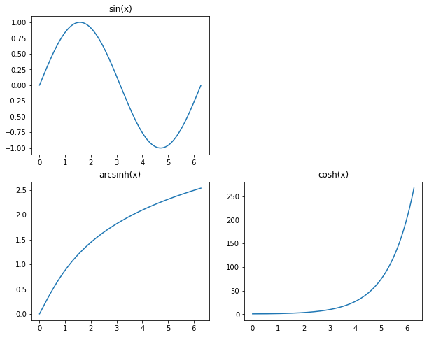

```python
fig = plt.figure(figsize=(10,8))

ax1 = fig.add_subplot(2, 2, 1, title='sin(x)');     ax1.plot(X,Y1)
# ax2 = fig.add_subplot(2, 2, 2, title='cos(x)');   ax2.plot(X,Y2) <-- remove this from canvas
ax3 = fig.add_subplot(2, 2, 3, title='arcsinh(x)'); ax3.plot(X,Y3)
ax4 = fig.add_subplot(2, 2, 4, title='cosh(x)');    ax4.plot(X,Y4)
```

- Jupyter notebook has a requirement: for multiple plots in a SAME axes and figure, all matplotlib code must be in the SAME cell

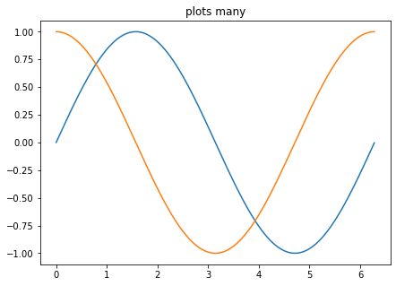

```python
# here we show that we can keep adding plots to the SAME axes:

fig = plt.figure(figsize=(7,5))

ax1 = fig.add_subplot(1, 1, 1, title='plots many')
ax1.plot(X,Y)
ax1.plot(X,Y2) # ax1.plot(X,Y3) etc
```

- ASIDE: `";"`
  - => output does NOT show: `[<matplotlib.lines.Line2D at 0x11865f9d0>]`

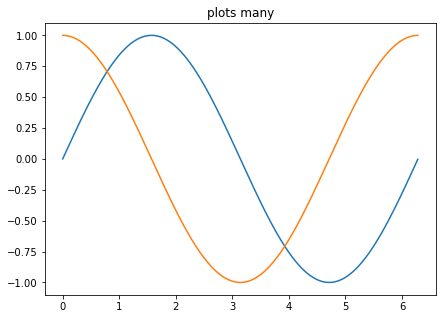

```python
fig = plt.figure(figsize=(7,5))

ax1 = fig.add_subplot(1, 1, 1, title='plots many')
ax1.plot(X,Y)
ax1.plot(X,Y2);
```

- interesting example (complicated)
  - plot the "Batman Curve"

```python
from numpy import sqrt
from numpy import meshgrid
from numpy import arange

xs = arange(-7.25, 7.25, 0.01)
ys = arange(-5, 5, 0.01)
x, y = meshgrid(xs, ys)

eq1 = ((x/7)**2*sqrt(abs(abs(x)-3)/(abs(x)-3))+(y/3)**2*sqrt(abs(y+3/7*sqrt(33))/(y+3/7*sqrt(33)))-1)
eq2 = (abs(x/2)-((3*sqrt(33)-7)/112)*x**2-3+sqrt(1-(abs(abs(x)-2)-1)**2)-y)
eq3 = (9*sqrt(abs((abs(x)-1)*(abs(x)-.75))/((1-abs(x))*(abs(x)-.75)))-8*abs(x)-y)
eq4 = (3*abs(x)+.75*sqrt(abs((abs(x)-.75)*(abs(x)-.5))/((.75-abs(x))*(abs(x)-.5)))-y)
eq5 = (2.25*sqrt(abs((x-.5)*(x+.5))/((.5-x)*(.5+x)))-y)
eq6 = (6*sqrt(10)/7+(1.5-.5*abs(x))*sqrt(abs(abs(x)-1)/(abs(x)-1))-(6*sqrt(10)/14)*sqrt(4-(abs(x)-1)**2)-y)
```

[figure not shown]

```python
plt.figure(figsize=(15,8))
for f in [eq1,eq2,eq3,eq4,eq5,eq6]:
    plt.contour(x, y, f, [0])
```

### Demonstration: real dataset

```python
df_resp = pd.read_csv('data/responses.csv')

#  young persons survey (lifestyle/music perferences)
```

```python
type(df_resp)
```

```
pandas.core.frame.DataFrame
```

#### what's in this dataset? column names?

```python
df_resp.columns
```

```
Index(['Music', 'Slow songs or fast songs', 'Dance', 'Folk', 'Country',
       'Classical music', 'Musical', 'Pop', 'Rock', 'Metal or Hardrock',
       ...
       'Age', 'Height', 'Weight', 'Number of siblings', 'Gender',
       'Left - right handed', 'Education', 'Only child', 'Village - town',
       'House - block of flats'],
      dtype='object', length=150)
```

```python
for columns in df_resp.columns:
    print(columns)
```

```
Music
Slow songs or fast songs
Dance
Folk
Country
Classical music
Musical
Pop
Rock
Metal or Hardrock
Punk
Hiphop, Rap
Reggae, Ska
Swing, Jazz
Rock n roll
Alternative
Latino
Techno, Trance
Opera
Movies
Horror
Thriller
Comedy
Romantic
Sci-fi
War
Fantasy/Fairy tales
Animated
Documentary
Western
Action
History
Psychology
Politics
Mathematics
Physics
Internet
PC
Economy Management
Biology
```

[output cut: 95 more lines]

```
Branded clothing
Entertainment spending
Spending on looks
Spending on gadgets
Spending on healthy eating
Age
Height
Weight
Number of siblings
Gender
Left - right handed
Education
Only child
Village - town
House - block of flats
```

```python
df_resp.head(10)
```

|  | Music | Slow songs or fast songs | Dance | Folk | Country | Classical music | Musical | Pop | Rock | Metal or Hardrock | ... | Age | Height | Weight | Number of siblings | Gender | Left - right handed | Education | Only child | Village - town | House - block of flats |
| --- | --- | --- | --- | --- | --- | --- | --- | --- | --- | --- | --- | --- | --- | --- | --- | --- | --- | --- | --- | --- | --- |
| 0 | 5.0 | 3.0 | 2.0 | 1.0 | 2.0 | 2.0 | 1.0 | 5.0 | 5.0 | 1.0 | ... | 20.0 | 163.0 | 48.0 | 1.0 | female | right handed | college/bachelor degree | no | village | block of flats |
| 1 | 4.0 | 4.0 | 2.0 | 1.0 | 1.0 | 1.0 | 2.0 | 3.0 | 5.0 | 4.0 | ... | 19.0 | 163.0 | 58.0 | 2.0 | female | right handed | college/bachelor degree | no | city | block of flats |
| 2 | 5.0 | 5.0 | 2.0 | 2.0 | 3.0 | 4.0 | 5.0 | 3.0 | 5.0 | 3.0 | ... | 20.0 | 176.0 | 67.0 | 2.0 | female | right handed | secondary school | no | city | block of flats |
| 3 | 5.0 | 3.0 | 2.0 | 1.0 | 1.0 | 1.0 | 1.0 | 2.0 | 2.0 | 1.0 | ... | 22.0 | 172.0 | 59.0 | 1.0 | female | right handed | college/bachelor degree | yes | city | house/bungalow |
| 4 | 5.0 | 3.0 | 4.0 | 3.0 | 2.0 | 4.0 | 3.0 | 5.0 | 3.0 | 1.0 | ... | 20.0 | 170.0 | 59.0 | 1.0 | female | right handed | secondary school | no | village | house/bungalow |
| 5 | 5.0 | 3.0 | 2.0 | 3.0 | 2.0 | 3.0 | 3.0 | 2.0 | 5.0 | 5.0 | ... | 20.0 | 186.0 | 77.0 | 1.0 | male | right handed | secondary school | no | city | block of flats |
| 6 | 5.0 | 5.0 | 5.0 | 3.0 | 1.0 | 2.0 | 2.0 | 5.0 | 3.0 | 1.0 | ... | 20.0 | 177.0 | 50.0 | 1.0 | female | right handed | secondary school | no | village | house/bungalow |
| 7 | 5.0 | 3.0 | 3.0 | 2.0 | 1.0 | 2.0 | 2.0 | 4.0 | 5.0 | 1.0 | ... | 19.0 | 184.0 | 90.0 | 1.0 | male | right handed | college/bachelor degree | no | city | house/bungalow |
| 8 | 5.0 | 3.0 | 3.0 | 1.0 | 1.0 | 2.0 | 4.0 | 3.0 | 5.0 | 5.0 | ... | 18.0 | 166.0 | 55.0 | 1.0 | female | right handed | secondary school | no | city | house/bungalow |
| 9 | 5.0 | 3.0 | 2.0 | 5.0 | 2.0 | 2.0 | 5.0 | 3.0 | 5.0 | 2.0 | ... | 19.0 | 174.0 | 60.0 | 3.0 | female | right handed | secondary school | no | city | block of flats |

10 rows × 150 columns

#### Let us focus on two columns

```python
x = df_resp['Weight']
y = df_resp['Height']
```

```python
x
```

```
0       48.0
1       58.0
2       67.0
3       59.0
4       59.0
        ...
1005    57.0
1006    80.0
1007    75.0
1008    58.0
1009    72.0
Name: Weight, Length: 1010, dtype: float64
```

```python
y
```

```
0       163.0
1       163.0
2       176.0
3       172.0
4       170.0
        ...
1005    164.0
1006    183.0
1007    173.0
1008    173.0
1009    185.0
Name: Height, Length: 1010, dtype: float64
```

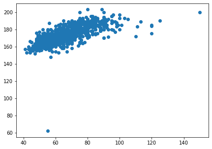

```python
fig = plt.figure(figsize=(7,5))

ax = fig.add_subplot(1,1,1)
ax.scatter(x, y);
```

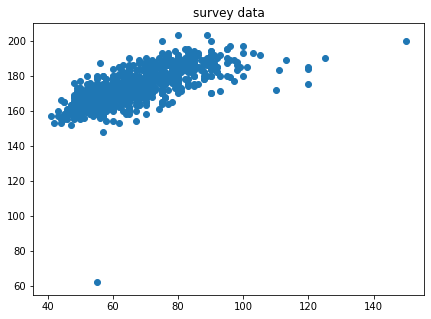

```python
fig = plt.figure(figsize=(7,5))

ax = fig.add_subplot(1,1,1, title = 'survey data') # add a title
ax.scatter(x, y);
```

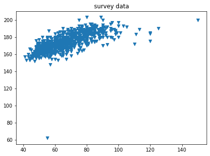

```python
fig = plt.figure(figsize=(7,5))

ax = fig.add_subplot(1,1,1, title = 'survey data')

ax.scatter(x, y, marker = 'v'); # try a different marker
# filled_markers = ('o', 'v', '^', '<', '>', '8', 's', 'p', '*', 'h', 'H', 'D', 'd', 'P', 'X')
```

Further Reading:

- https://matplotlib.org/api/_as_gen/matplotlib.markers.MarkerStyle.html#matplotlib.markers.MarkerStyle

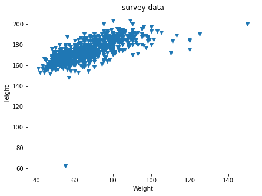

```python
fig = plt.figure(figsize=(7,5))

ax = fig.add_subplot(1,1,1, title = 'survey data')
ax.scatter(x, y, marker = 'v')

ax.set_xlabel('Weight') # X and Y axis labels
ax.set_ylabel('Height');
```

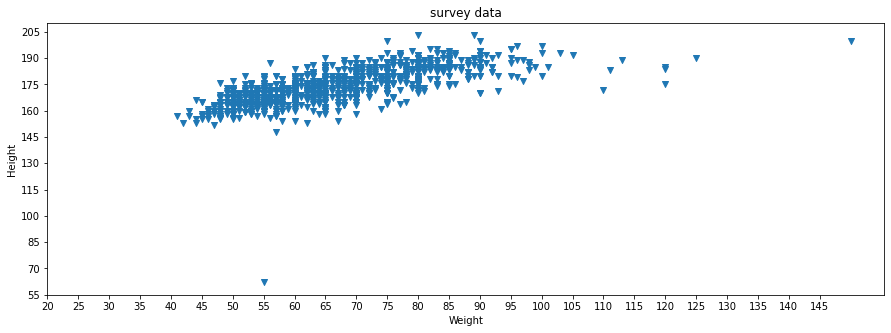

```python
fig = plt.figure(figsize=(15,5)) # wider figure to help see axis labels

ax = fig.add_subplot(1,1,1, title = 'survey data')
ax.scatter(x, y, marker = 'v')
ax.set_xlabel('Weight')
ax.set_ylabel('Height')

ax.set_xticks(np.arange(20, 150, 5))     # add scaled axes, increase the overall size of the graph
ax.set_yticks(np.arange(55, 220, 15));   # notice that 220 is not visible, how can we fix this?
```

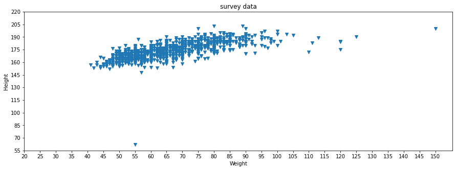

```python
fig = plt.figure(figsize=(15,5))

ax = fig.add_subplot(1,1,1, title = 'survey data')
ax.scatter(x, y, marker = 'v')
ax.set_xlabel('Weight')
ax.set_ylabel('Height')

ax.set_xticks(np.arange(20, 150 + 1, 5))     # "+ 1" so we can see the whole plot
ax.set_yticks(np.arange(55, 220 + 1, 15));
```

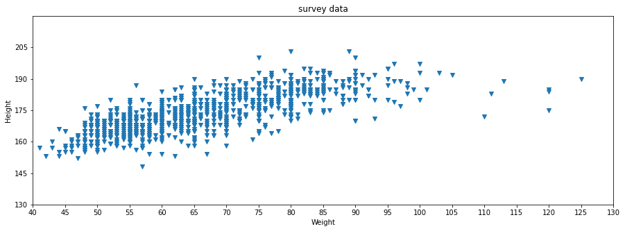

```python
fig = plt.figure(figsize=(15,5))

ax = fig.add_subplot(1,1,1, title = 'survey data')
ax.scatter(x, y, marker = 'v')
ax.set_xlabel('Weight')
ax.set_ylabel('Height')

ax.set_xticks(np.arange(20, 150, 5))
ax.set_yticks(np.arange(55, 220, 15))

ax.set_xlim(40, 130, 5)    # show only the bulk of the data (we could rescale the axes)
ax.set_ylim(130, 220, 15);
```

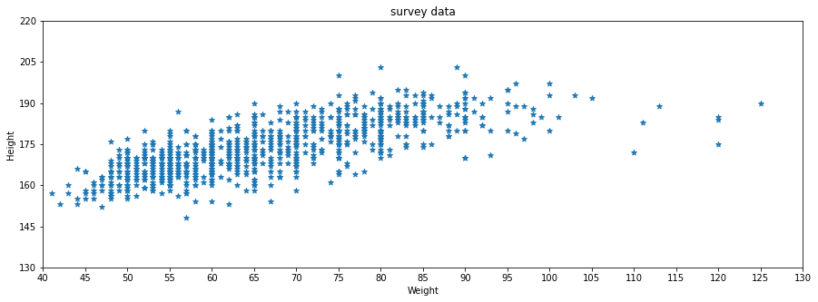

```python
fig = plt.figure(figsize=(15,5))

ax = fig.add_subplot(1,1,1, title = 'survey data')
ax.scatter(x, y, marker = '*')                    # pizzazz
ax.set_xlabel('Weight')
ax.set_ylabel('Height')

ax.set_xticks(np.arange(20, 150 + 1, 5))
ax.set_yticks(np.arange(55, 220 + 1, 15))

ax.set_xlim(40, 130, 5)
ax.set_ylim(130, 220, 15);
```

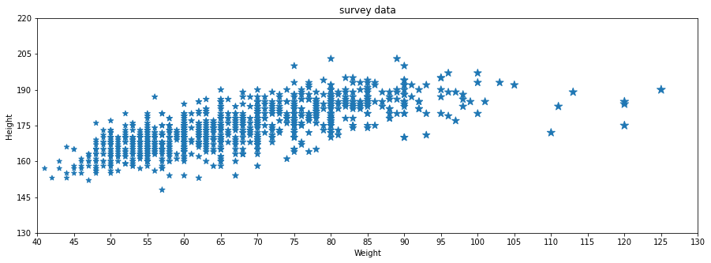

```python
fig = plt.figure(figsize=(15,5))

ax = fig.add_subplot(1,1,1, title = 'survey data')
ax.scatter(x, y, marker = '*', s = df_resp['Weight']) # size based on weight
ax.set_xlabel('Weight')
ax.set_ylabel('Height')

ax.set_xticks(np.arange(20, 150 + 1, 5))
ax.set_yticks(np.arange(55, 220 + 1, 15))

ax.set_xlim(40, 130, 5)
ax.set_ylim(130, 220, 15);
```

##### can we add some colour to the plot?

```
ax.scatter(x, y, marker = '*', s = df_resp['Weight'],

           # colour arguement
           c = df_resp['Gender']
          )
```

causes a ValueError due to string

how to avoid?

- mpl color, or a sequence of mpl colors, or
- a sequence of numbers

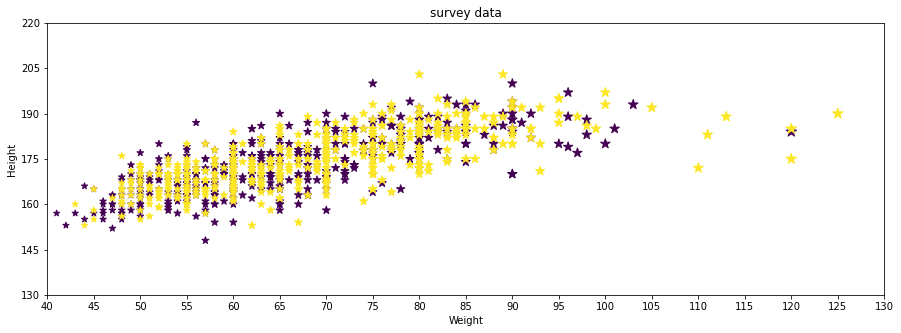

```python
fig = plt.figure(figsize=(15,5))

ax = fig.add_subplot(1,1,1, title = 'survey data')
ax.scatter(x, y, marker = '*', s = df_resp['Weight'],

           # colour
           c = pd.Series([0, 1]).repeat(len(df_resp)/2))

ax.set_xlabel('Weight'); ax.set_ylabel('Height'); ax.set_xticks(np.arange(20, 150 + 1, 5)); ax.set_yticks(np.arange(55, 220 + 1, 15)) ; ax.set_xlim(40, 130, 5); ax.set_ylim(130, 220, 15);
```

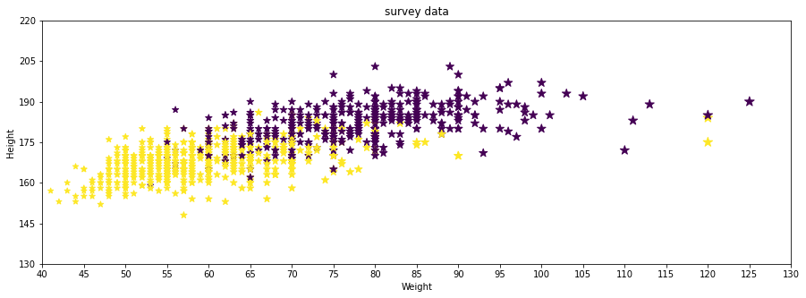

```python
fig = plt.figure(figsize=(15,5))
ax = fig.add_subplot(1,1,1, title = 'survey data')
ax.scatter(x, y, marker = '*', s = df_resp['Weight'],

           # colour              enumerate from str to int
           c = df_resp['Gender'].replace(['male', 'female'], [0,1])
          )

ax.set_xlabel('Weight'); ax.set_ylabel('Height'); ax.set_xticks(np.arange(20, 150 + 1, 5)); ax.set_yticks(np.arange(55, 220 + 1, 15)) ; ax.set_xlim(40, 130, 5); ax.set_ylim(130, 220, 15);
```

```python
fig.savefig('WeightVsHeight_c.png')
```